# Exploratory Data Analysis on Prosper P2P Lending Data

Prosper Marketplace, Inc. is a San Francisco, California based company that does peer-to-peer lending. It’s the first peer-to-peer lending marketplace in the industry, with over $7 billion in funded loans. Borrowers request personal loans on Prosper, while investors can fund the loans, considering the borrower’s credit scores, ratings, histories, and category of the loan. Prosper handles the servicing of the loan, and collects and distributes payments and interests to the investors.

The Prosper’s Lending Data (last updated on 03/11/2014) can be downloaded [here](https://s3.amazonaws.com/udacity-hosted-downloads/ud651/prosperLoanData.csv) and the variable dictionary is [here](https://docs.google.com/spreadsheets/d/1gDyi_L4UvIrLTEC6Wri5nbaMmkGmLQBk-Yx3z0XDEtI/edit#gid=0)

With the data loaded, I’ll do a quick check on the types of variables in this large dataset.

```
## 'data.frame':    113937 obs. of  81 variables:
##  $ ListingKey                         : Factor w/ 113066 levels "00003546482094282EF90E5",..: 7180 7193 6647 6669 6686 6689 6699 6706 6687 6687 ...
##  $ ListingNumber                      : int  193129 1209647 81716 658116 909464 1074836 750899 768193 1023355 1023355 ...
##  $ ListingCreationDate                : Factor w/ 113064 levels "2005-11-09 20:44:28.847000000",..: 14184 111894 6429 64760 85967 100310 72556 74019 97834 97834 ...
##  $ CreditGrade                        : Factor w/ 8 levels "A","AA","B","C",..: 4 NA 7 NA NA NA NA NA NA NA ...
##  $ Term                               : int  36 36 36 36 36 60 36 36 36 36 ...
##  $ LoanStatus                         : Factor w/ 12 levels "Cancelled","Chargedoff",..: 3 4 3 4 4 4 4 4 4 4 ...
##  $ ClosedDate                         : Factor w/ 2802 levels "2005-11-25 00:00:00",..: 1137 NA 1262 NA NA NA NA NA NA NA ...
##  $ BorrowerAPR                        : num  0.165 0.12 0.283 0.125 0.246 ...
##  $ BorrowerRate                       : num  0.158 0.092 0.275 0.0974 0.2085 ...
##  $ LenderYield                        : num  0.138 0.082 0.24 0.0874 0.1985 ...
##  $ EstimatedEffectiveYield            : num  NA 0.0796 NA 0.0849 0.1832 ...
##  $ EstimatedLoss                      : num  NA 0.0249 NA 0.0249 0.0925 ...
##  $ EstimatedReturn                    : num  NA 0.0547 NA 0.06 0.0907 ...
##  $ ProsperRating..numeric.            : int  NA 6 NA 6 3 5 2 4 7 7 ...
```

[output cut: 67 more lines]

Since ProsperScore and ProsperRating..Alpha can only take a limited number of different values, I’m converting them into factor variables and rearranging them to display better.

```
##  Ord.factor w/ 11 levels "1"<"2"<"3"<"4"<..: NA 7 NA 9 4 10 2 4 9 11 ...
```

```
##  Ord.factor w/ 7 levels "HR"<"E"<"D"<"C"<..: NA 6 NA 6 3 5 2 4 7 7 ...
```

> This dataset contains 113,937 loans with 81 variables on each loan, including loan amount, borrower rate (or interest rate), current loan status, borrower income, borrower employment status, borrower credit history, and the latest payment information.

# Univariate Plots Section

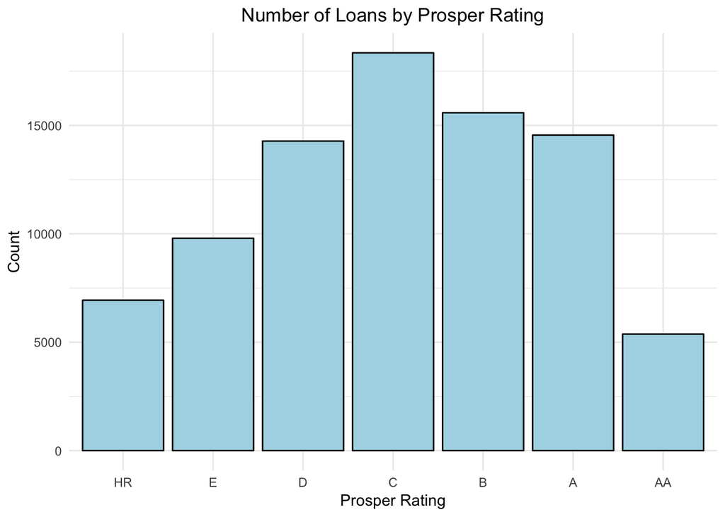

```
##    HR     E     D     C     B     A    AA
##  6935  9795 14274 18345 15581 14551  5372
```

> It seems the loan ratings are normally distributed, with “C” ratings being the most frequent.

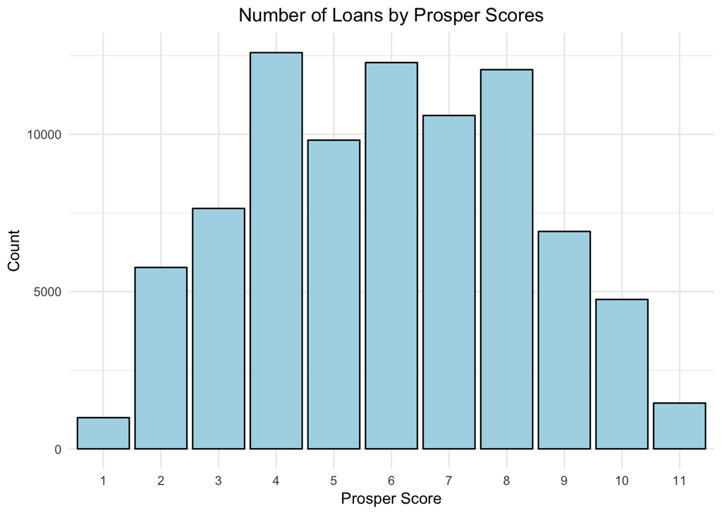

```
##     1     2     3     4     5     6     7     8     9    10    11
##   992  5766  7642 12595  9813 12278 10597 12053  6911  4750  1456
```

> It seems the distribution of Prosper Scores is similar to the distribution of Prosper Rating. The most concentrated area is between scores 4 to 8.

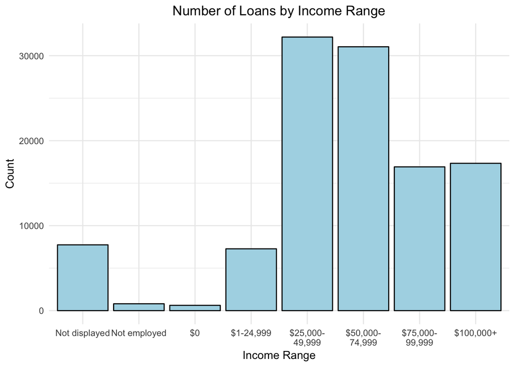

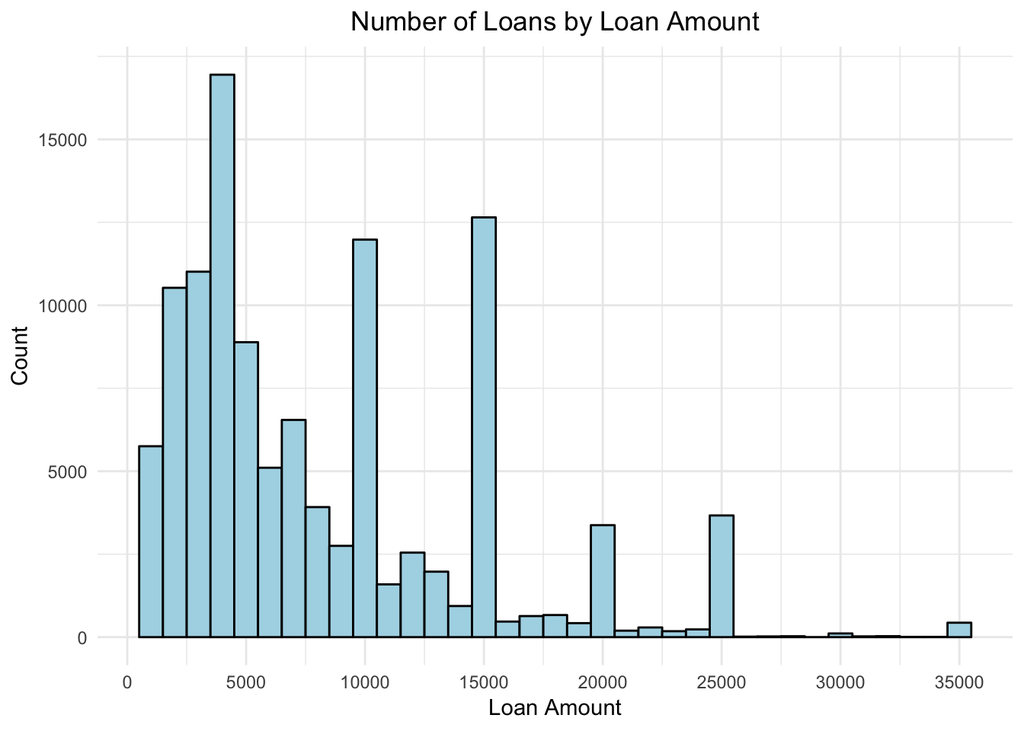

```
##    Min. 1st Qu.  Median    Mean 3rd Qu.    Max.
##    1000    4000    6500    8337   12000   35000
```

> It seems most people took loan amounts of under $10,000. One interesting observation is that the # of loans spike at $5,000 intervals, as seen in $10,000, $15,000, $20,000, etc. Is it possible people lean towards amounts by the $5,000s? Or perhaps Prosper has a selection list of amounts that are multiples of $5,000, and let customers specify amounts if their desired amount is not in the selection list?

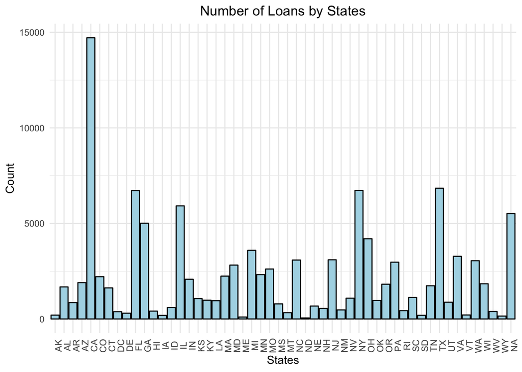

```
##    AK    AL    AR    AZ    CA    CO    CT    DC    DE    FL    GA    HI
##   200  1679   855  1901 14717  2210  1627   382   300  6720  5008   409
##    IA    ID    IL    IN    KS    KY    LA    MA    MD    ME    MI    MN
##   186   599  5921  2078  1062   983   954  2242  2821   101  3593  2318
##    MO    MS    MT    NC    ND    NE    NH    NJ    NM    NV    NY    OH
##  2615   787   330  3084    52   674   551  3097   472  1090  6729  4197
##    OK    OR    PA    RI    SC    SD    TN    TX    UT    VA    VT    WA
##   971  1817  2972   435  1122   189  1737  6842   877  3278   207  3048
##    WI    WV    WY  NA's
##  1842   391   150  5515
```

> Nothing too interesting here - states with large cities have more people, and therefore account for more loans than states with smaller cities.

```
##
##     0     1     2     3     4     5     6     7     8     9    10    11
## 16965 58308  7433  7189  2395   756  2572 10494   199    85    91   217
##    12    13    14    15    16    17    18    19    20
##    59  1996   876  1522   304    52   885   768   771
```

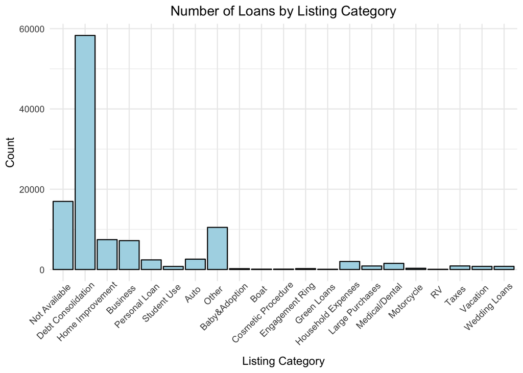

```
##
##      Not Available Debt Consolidation   Home Improvement
##              16965              58308               7433
##           Business      Personal Loan        Student Use
##               7189               2395                756
##               Auto              Other      Baby&Adoption
##               2572              10494                199
##               Boat Cosmetic Procedure    Engagement Ring
##                 85                 91                217
##        Green Loans Household Expenses    Large Purchases
##                 59               1996                876
##     Medical/Dental         Motorcycle                 RV
##               1522                304                 52
##              Taxes           Vacation      Wedding Loans
##                885                768                771
```

> One category stands far above the rest, and that is Debt Consolidation. This makes sense, since a lot of people in debt can potentially have high-interest loans from elsewhere. Getting a great rate from Prosper could save on massive amount of interest from those high-interest loans.

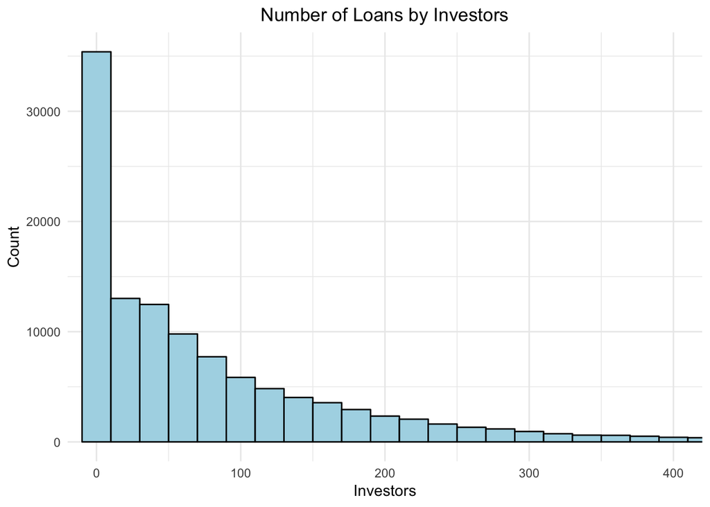

```
##    Min. 1st Qu.  Median    Mean 3rd Qu.    Max.
##    1.00    2.00   44.00   80.48  115.00 1189.00
```

> It seems a sizeable number of loans are bought out by individual investors, with the majority of the loans bought out by fewer than 100 investors. Not quite surprising, since loan amounts (as seen before) are usually less than $10,000, which can be covered a single investor comfortably.

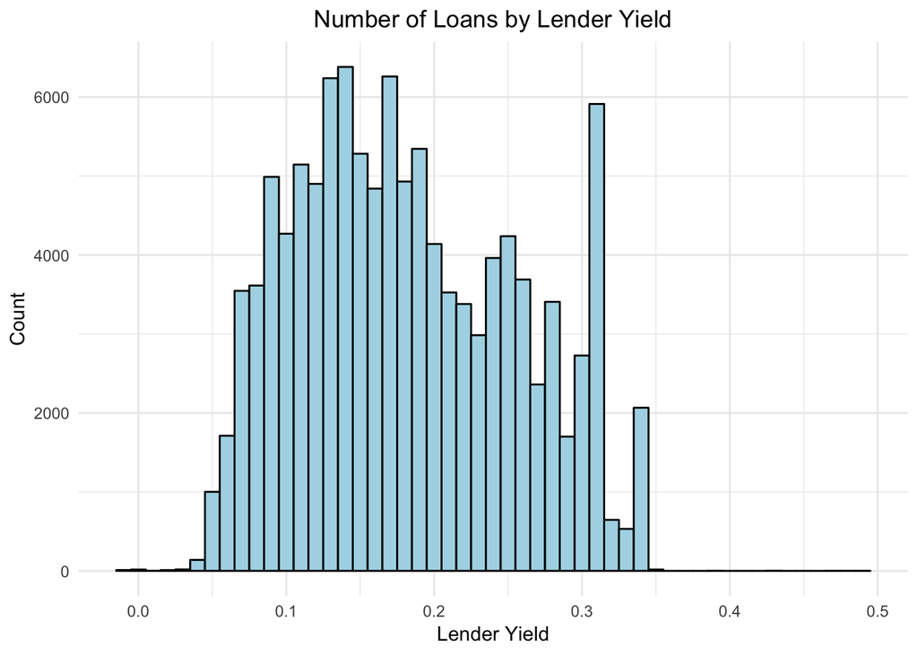

```
##    Min. 1st Qu.  Median    Mean 3rd Qu.    Max.
## -0.0100  0.1242  0.1730  0.1827  0.2400  0.4925
```

> Based on the plot, most yields are between 5% to 35%, with most of them concentrated near 17%.

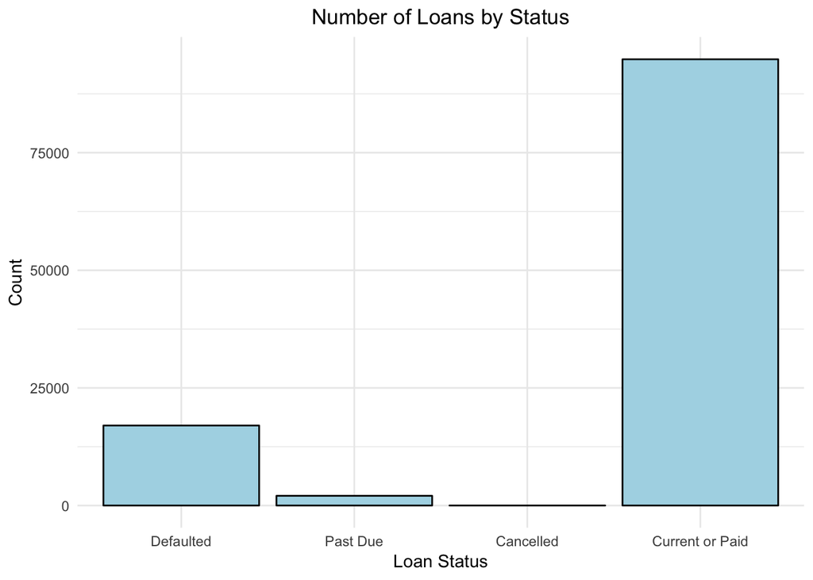

```
##              Cancelled             Chargedoff              Completed
##                      5                  11992                  38074
##                Current              Defaulted FinalPaymentInProgress
##                  56576                   5018                    205
##   Past Due (>120 days)   Past Due (1-15 days)  Past Due (16-30 days)
##                     16                    806                    265
##  Past Due (31-60 days)  Past Due (61-90 days) Past Due (91-120 days)
##                    363                    313                    304
```

> It seems the majority of all loans in the dataset are in good standing. If anything else, this reflects nicely on Prosper as a platform for peer-to-peer lending, since many people, including me, had doubts about the safety of investing in non-traditional loans.

# Univariate Analysis

### Main feature(s) of interest in the dataset

I want to determine whether the **Loan Status** of a loan is connected or affected by certain variables, such as yields or whether the income or ratings of the loaners are good. I also want to check out how the **Lender Yield** is affected by things like credit scores and Prosper scores.

Credit scores and loan terms can be considered as well. Since credit score is tied to how consistent borrowers can pay back what they borrowed, it would make sense for investors to invest in loans by borrowers with good credit scores, or else borrowers with bad credit score can just default or delay payment. On the other hand, loan terms may be important to certain people, whether they are looking for something long term or short term.

### Introduction of New Variables

I introduced the ProsperRating and Status variables, and set them to be ordered factor variables.

### Reflection on the distributions and cleaning

There were some unusual distributions, such as Number of Loans by Investors and Number of Loans by Loan Amount. These two are mostly skewed to the right.

I did factorize and ordered a few variables. I did this because statistical models treat numeric and factor variables differently, as well as unordered and ordered factor variables. To make sure the models calculate using the correct method, I had to make sure the variables I’m investigating are of the right data type.

# Bivariate Plots Section

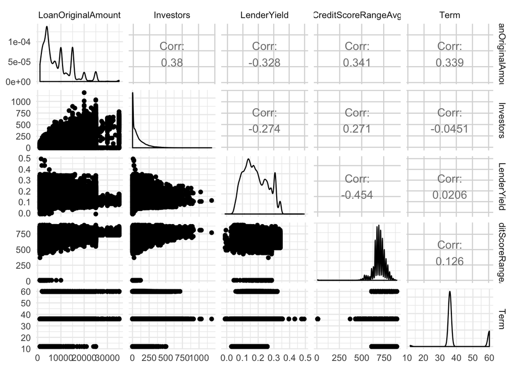

```
##                    LoanOriginalAmount  Investors LenderYield
## LoanOriginalAmount          1.0000000  0.3800926  -0.3284551
## Investors                   0.3800926  1.0000000  -0.2741739
## LenderYield                -0.3284551 -0.2741739   1.0000000
```

> A quick correlation matrix shows that the continuous variables LoanOriginalAmount, Investors, LenderYield, CreditScoreRangeAvg, and Term do not have a strong correlation amongst each other. I do want to check out the relationship (if any) between Score and Rating with the Investors variable.

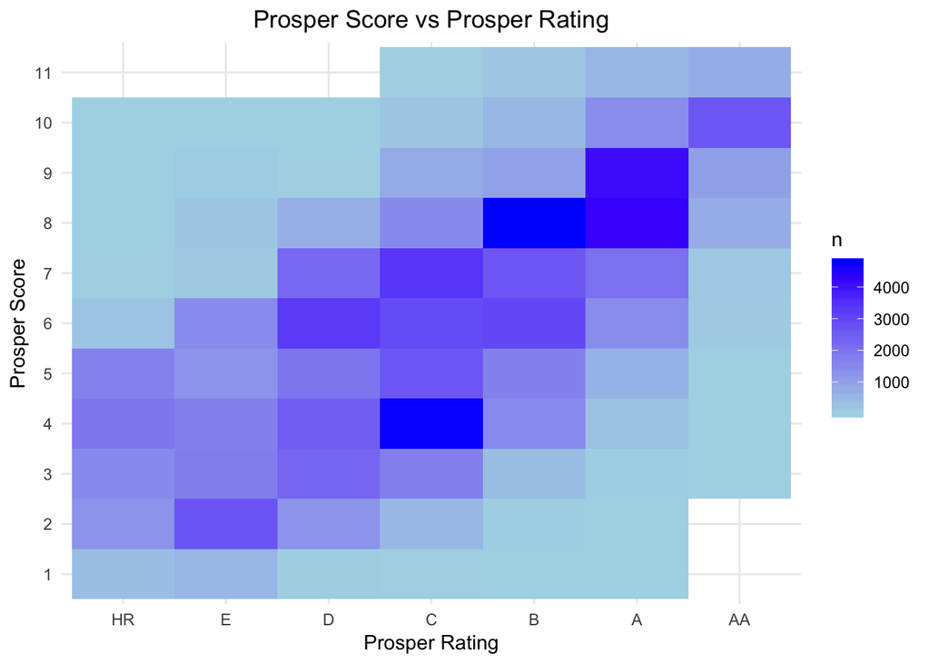

> Based on this scatterplot, it seems rating and score have a positive linear relationship; higher ratings tend to result in higher scores. I suspect that the relationships between Investors and both Rating and Score should be similar. Let’s find out.

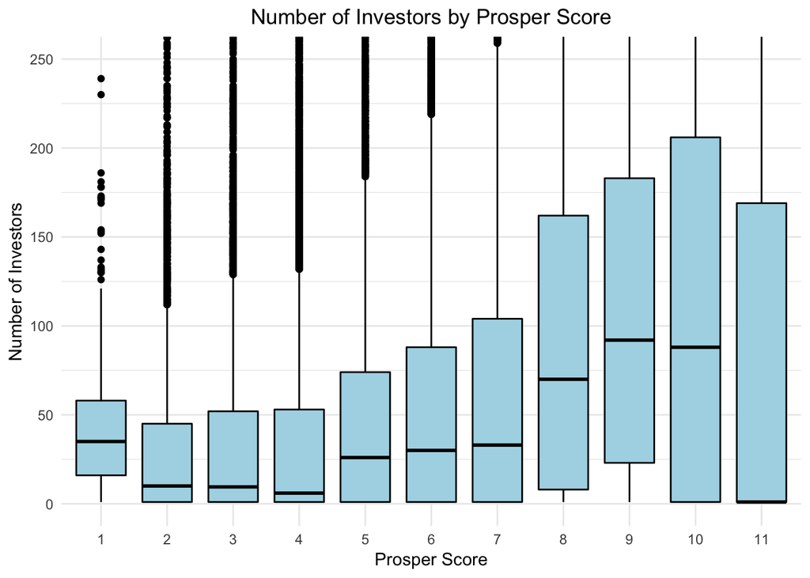

```
## prosper$ProsperScore: 1
##    Min. 1st Qu.  Median    Mean 3rd Qu.    Max.
##    1.00   16.00   35.00   40.78   58.00  293.00
## --------------------------------------------------------
## prosper$ProsperScore: 2
##    Min. 1st Qu.  Median    Mean 3rd Qu.    Max.
##     1.0     1.0    10.0    30.3    45.0   470.0
## --------------------------------------------------------
## prosper$ProsperScore: 3
##    Min. 1st Qu.  Median    Mean 3rd Qu.    Max.
##    1.00    1.00    9.50   35.24   52.00  483.00
## --------------------------------------------------------
## prosper$ProsperScore: 4
##    Min. 1st Qu.  Median    Mean 3rd Qu.    Max.
##    1.00    1.00    6.00   36.88   53.00  833.00
## --------------------------------------------------------
## prosper$ProsperScore: 5
##    Min. 1st Qu.  Median    Mean 3rd Qu.    Max.
##    1.00    1.00   26.00   51.72   74.00 1024.00
## --------------------------------------------------------
## prosper$ProsperScore: 6
##    Min. 1st Qu.  Median    Mean 3rd Qu.    Max.
##    1.00    1.00   30.00   59.62   88.00  821.00
## --------------------------------------------------------
## prosper$ProsperScore: 7
##    Min. 1st Qu.  Median    Mean 3rd Qu.    Max.
##    1.00    1.00   33.00   67.78  104.00 1035.00
## --------------------------------------------------------
## prosper$ProsperScore: 8
##    Min. 1st Qu.  Median    Mean 3rd Qu.    Max.
##     1.0     8.0    70.0   105.7   162.0  1189.0
## --------------------------------------------------------
## prosper$ProsperScore: 9
##    Min. 1st Qu.  Median    Mean 3rd Qu.    Max.
##     1.0    23.0    92.0   121.5   183.0   659.0
## --------------------------------------------------------
## prosper$ProsperScore: 10
##    Min. 1st Qu.  Median    Mean 3rd Qu.    Max.
##     1.0     1.0    88.0   133.6   206.0   779.0
## --------------------------------------------------------
## prosper$ProsperScore: 11
##    Min. 1st Qu.  Median    Mean 3rd Qu.    Max.
##     1.0     1.0     1.0    94.3   169.0   714.0
```

```
## # A tibble: 12 x 2
##    ProsperScore     n
##           <ord> <int>
##  1            1   992
##  2            2  5766
##  3            3  7642
##  4            4 12595
##  5            5  9813
##  6            6 12278
##  7            7 10597
##  8            8 12053
##  9            9  6911
## 10           10  4750
## 11           11  1456
## 12         <NA> 29084
```

> It seems that as we go higher on the Prosper Scoring scale of 1 through 11, the median of number of investors for a given loan goes up. The interesting thing is at the score of 11, the median is 1. One explanation may be that since the score is so high and the loan yield is almost guaranteed, individual investors buy out the entirety of the loan amount.

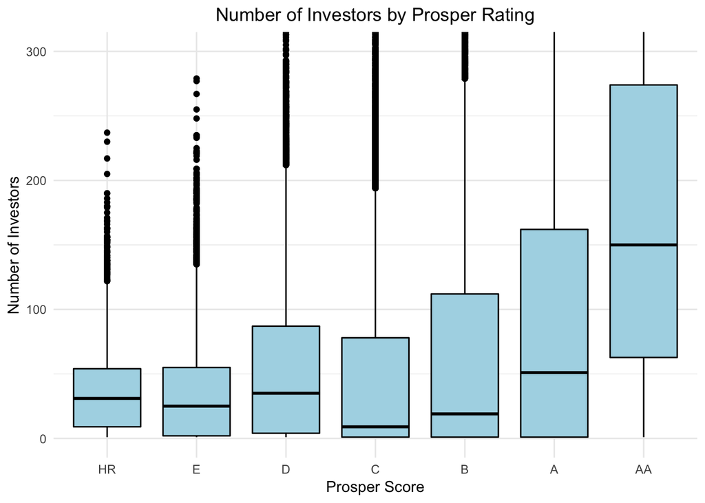

> This plot maintains my original claim that better score/rating usually results in higher number of investors. Now let’s examine a few other relationships.

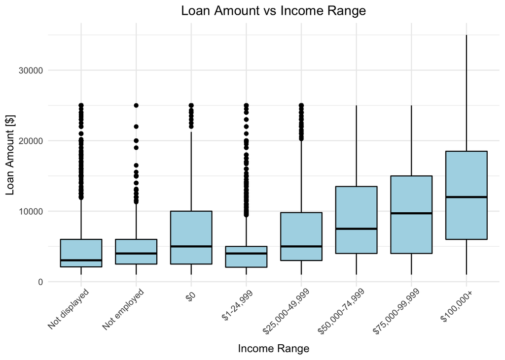

> This graph is showing a peculiar relationship: it seems that as the income level goes up, there is more money borrowed in a loan. One would think having a higher income would reduce the need to take out a loan for high value assets like houses, cars, etc. But quite on the contrary, the relationship between income and loan amount is direct, not inverse. Perhaps people of different income levels have different priorities - people with high income may categorize things like starting a business or other expensive ventures as high priority. People with low income would probably categorize paying off debt as high priority. It’s also *possible* that people with higher income tend to buy the same things as others, but higher quality, hence a slightly increase in median loan amount. This prompts a Loan Category vs Income Range exploration.

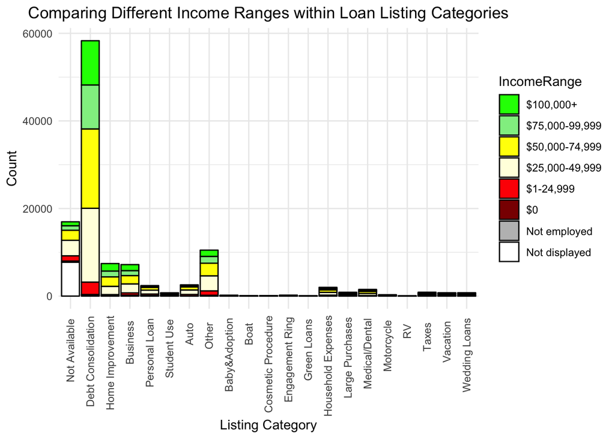

> Judging by this chart, debt consolidation is a huge piece of the puzzle, for people from all socio-economic classes. Without further debt data to breakdown, it’s hard for me to tell why people with high income have to take out larger loans than people with lower income. Is it their spending habit? Or perhaps in certain areas (Bay Area), $100k salary is considered only average? Moving on.

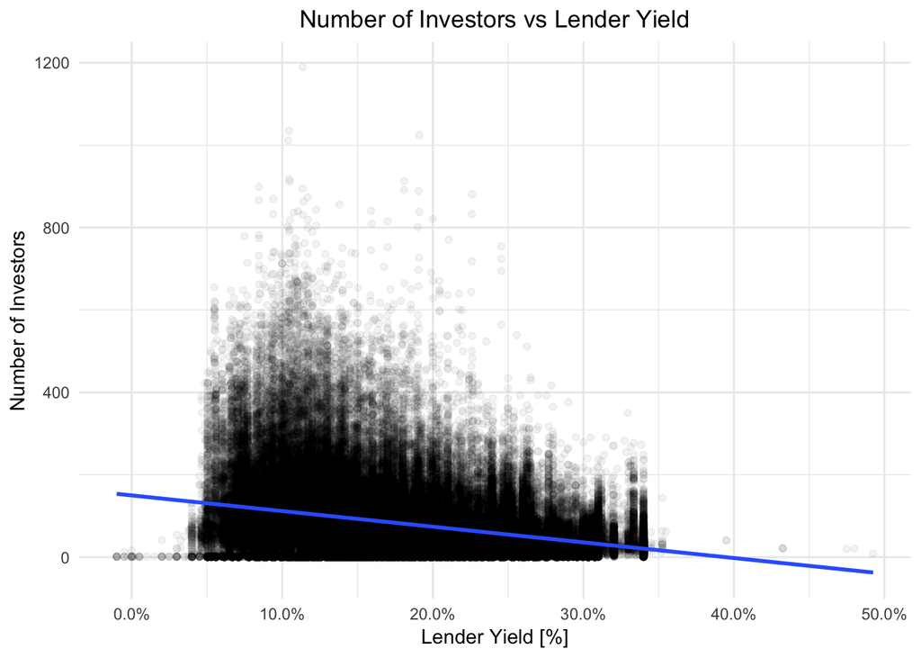

```
## [1] -0.2741739
```

> As previously observed in the matrix table, higher lender yield actually results in a slight decrease in number of investors. Perhaps higher yield usually means higher risk, and it’s a common phenomenon that more people are risk-averse than not.

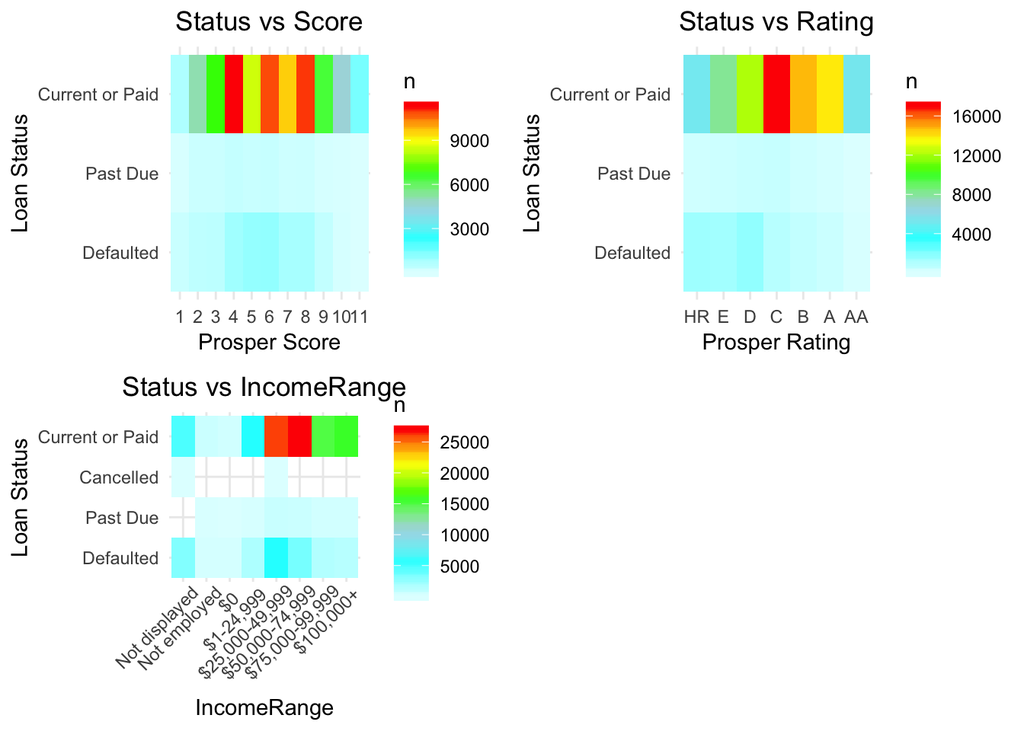

> Having high income doesn’t neccessarily mean the borrower will not default. Having high Prosper Rating and Scores does seem to affect the number of defaults - the occurances of Past Dues and Defaults seem to become very rare at very high score/rating (when score = 10 or 11, rating = A or AA). This, plus the original plot of “Number of Investors vs Prosper Rating”, makes a lot of sense, since investors would not appreciate their investments go down the drain.

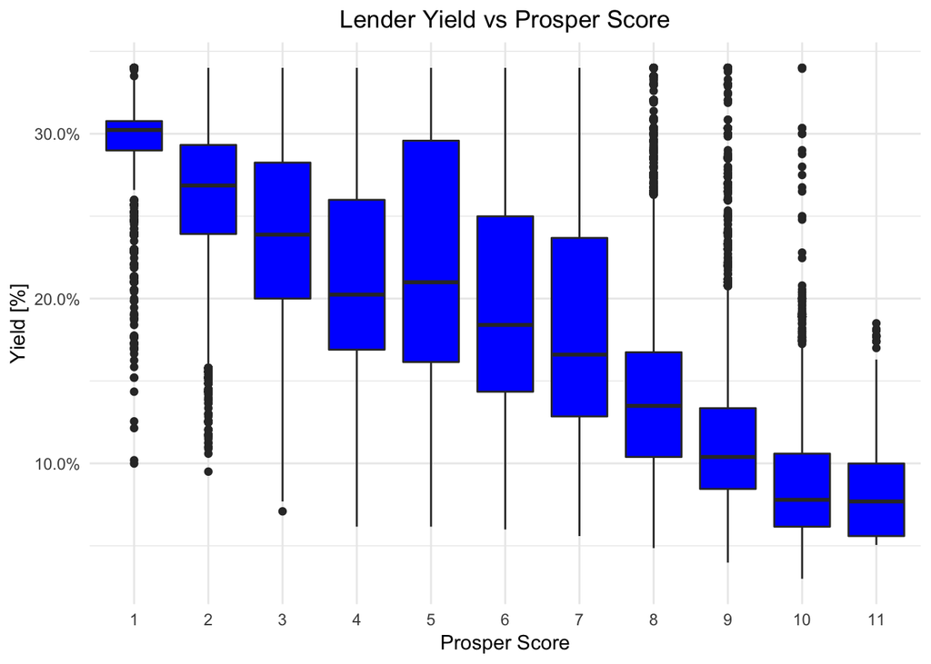

> We now see a much clearer picture. Higher scores usually result in lower yield, since there is lower risk involved.

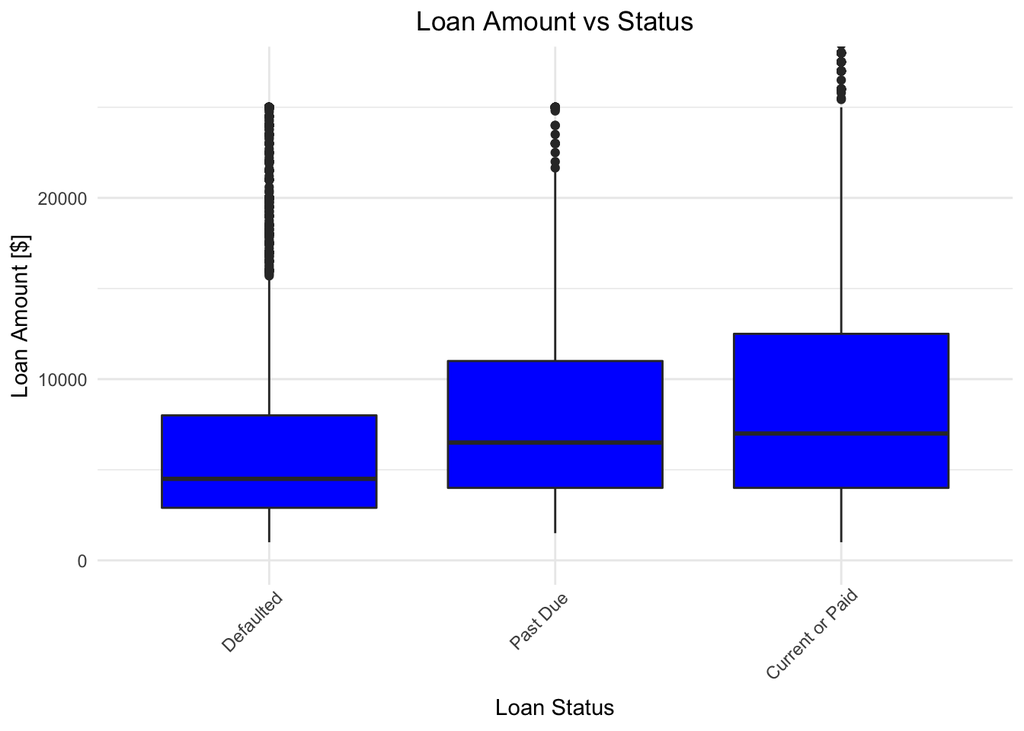

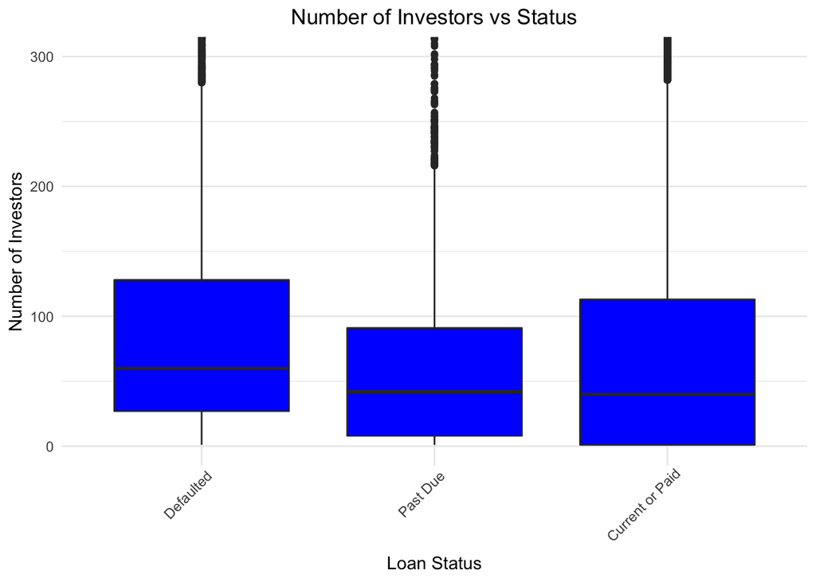

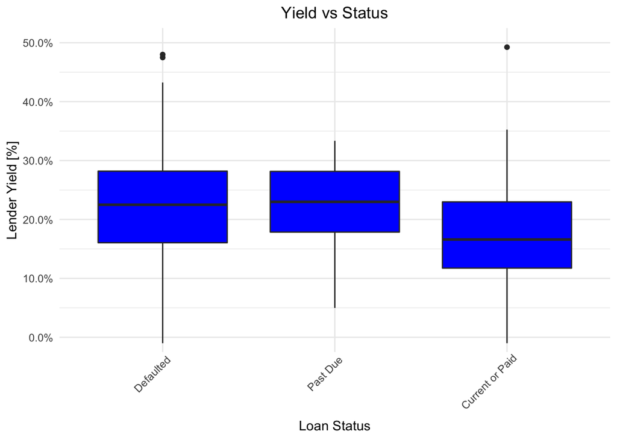

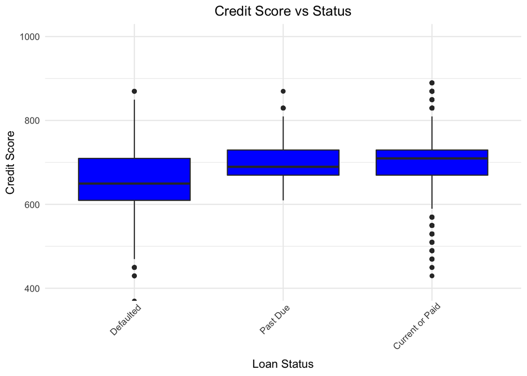

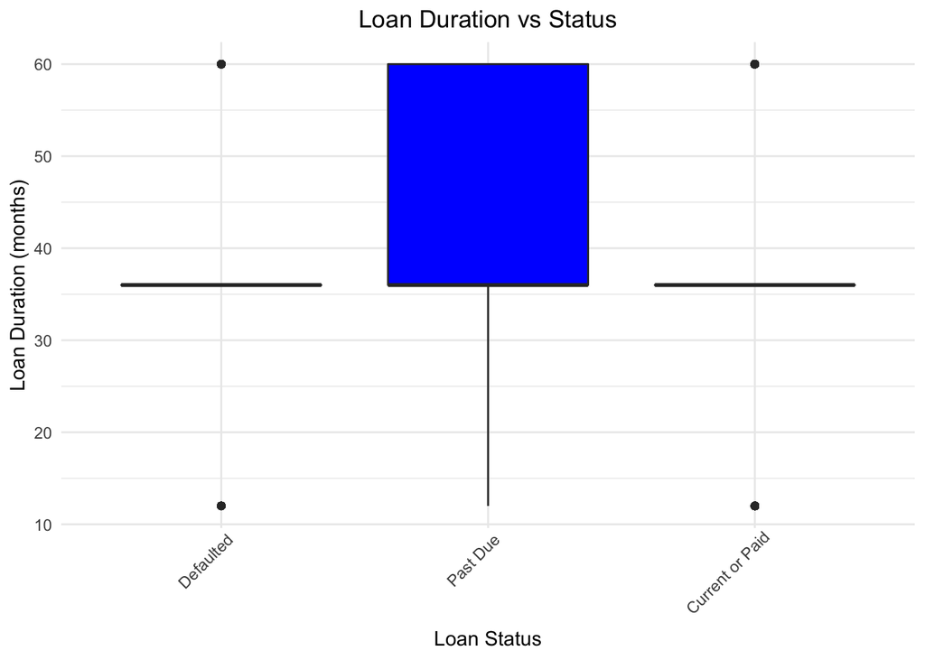

> By looking at the boxplots, the picture becomes much more clear. I will discuss more about the relationships in the Bivariate Analysis section below.

# Bivariate Analysis

### Relationships and Observations on the Main Features

Based on the last bivariate plot, when comparing good-standing loans to loans that are not, I found that: 1) Loans that are in good-standing have higher median loan amount, 2) Loans that are in good-standing have fewer median number of investors, 3) Loans that are in good-standing have lower median yield, 4) The people requesting loans that are in good-standing have a higher median credit score, and 5) No major difference in loan duration between good-standing loans and the delinquent ones.

### Relationships of other interesting variables

Some other interesting relationships I found are: * Median Yield goes down as Prosper Score goes up * Number of Investors goes down as Yield goes up * Out of all the listing categories, a huge chunk of loans belong to the “Debt Consolidation” category, and also people who are relatively well-off (salary of $75k or above) have most of their loans in this category. * Loan amount increases as income level increases * Median number of Investors goes up as Prosper score or rating goes up

### Strongest Relationship

The strongest relationship is definitely Median Lender Yield vs Prosper Score. It confirms our common knowledge that the higher the Prosper Score, the lower the yield. “High risk, high reward”, as people always say.

# Multivariate Plots Section

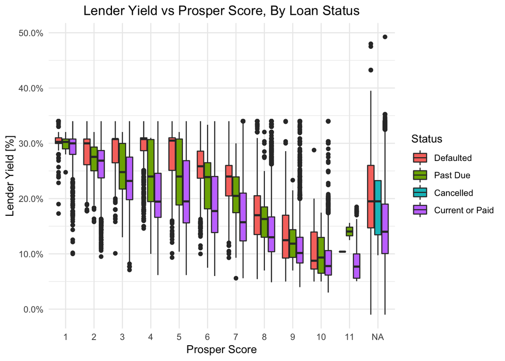

> What I discussed before in the bivariate analysis section still can be seen here: as Prosper Score increases, yield decreases for loans of all statuses. Although, loans that are in good-standing have slightly lower yield than the others across the board. This is probably because there are other variables affecting yield, such as current delinquent amount or credit scores.

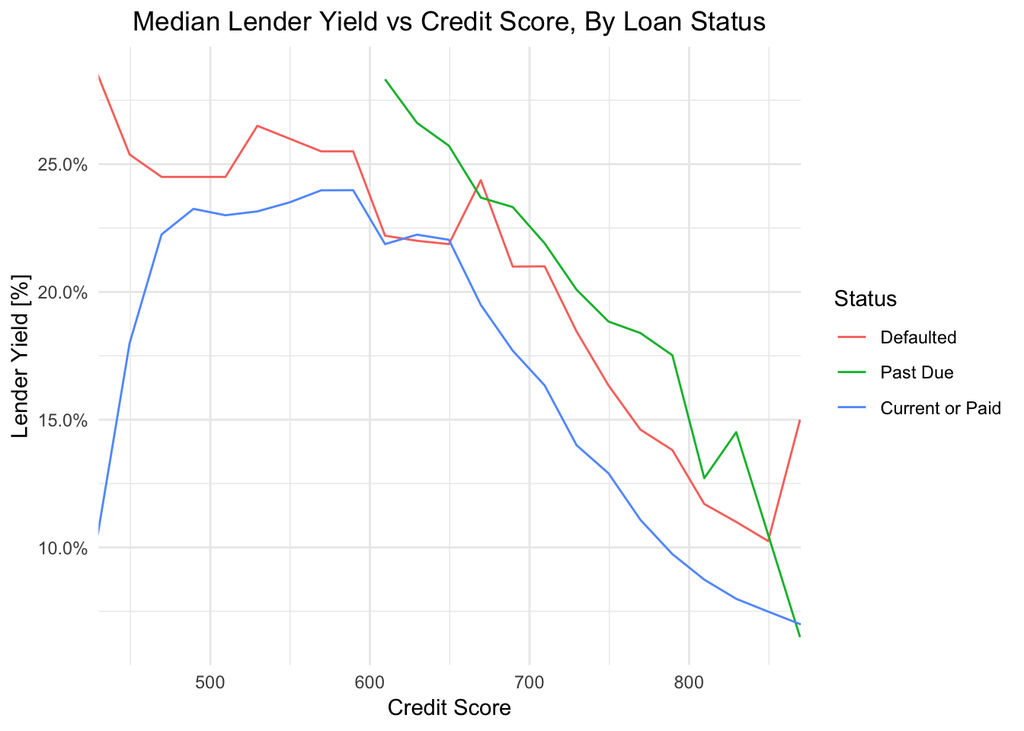

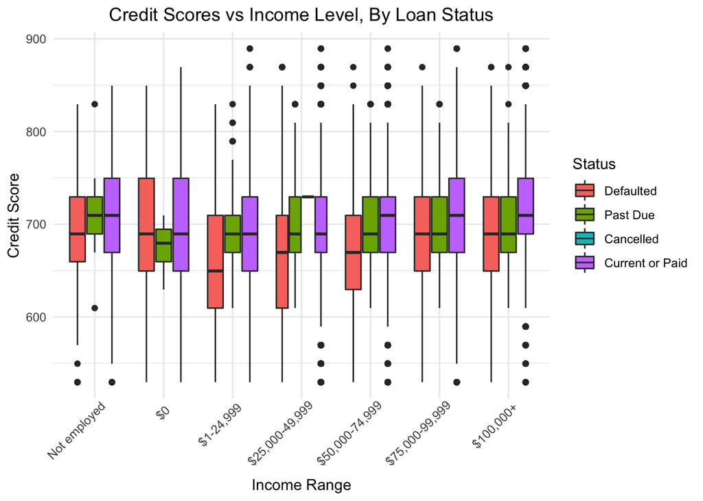

```
##
## Calls:
## m1: lm(formula = LenderYield ~ ProsperScore, data = prosper)
## m2: lm(formula = LenderYield ~ ProsperScore + LoanOriginalAmount,
##     data = prosper)
## m3: lm(formula = LenderYield ~ ProsperScore + LoanOriginalAmount +
##     CreditScoreRangeAvg, data = prosper)
## m4: lm(formula = LenderYield ~ ProsperScore + LoanOriginalAmount +
##     CreditScoreRangeAvg + AmountDelinquent, data = prosper)
## m5: lm(formula = LenderYield ~ ProsperScore + LoanOriginalAmount +
##     CreditScoreRangeAvg + AmountDelinquent + Status, data = prosper)
##
## =====================================================================================================================
##                                            m1              m2              m3              m4              m5
## ---------------------------------------------------------------------------------------------------------------------
##   (Intercept)                              0.184***        0.213***        0.496***        0.495***        0.531***
##                                           (0.000)         (0.000)         (0.003)         (0.003)         (0.003)
##   ProsperScore: .L                        -0.219***       -0.192***       -0.165***       -0.165***       -0.159***
##                                           (0.001)         (0.001)         (0.001)         (0.001)         (0.001)
##   ProsperScore: .Q                        -0.010***       -0.009***       -0.006***       -0.006***       -0.008***
##                                           (0.001)         (0.001)         (0.001)         (0.001)         (0.001)
##   ProsperScore: .C                        -0.003**         0.003**         0.002*          0.002*          0.007***
##                                           (0.001)         (0.001)         (0.001)         (0.001)         (0.001)
##   ProsperScore: ^4                         0.026***        0.030***        0.021***        0.021***        0.016***
##                                           (0.001)         (0.001)         (0.001)         (0.001)         (0.001)
##   ProsperScore: ^5                         0.005***        0.006***        0.003***        0.003***        0.005***
##                                           (0.001)         (0.001)         (0.001)         (0.001)         (0.001)
##   ProsperScore: ^6                        -0.006***       -0.004***       -0.008***       -0.008***       -0.009***
##                                           (0.001)         (0.001)         (0.001)         (0.001)         (0.001)
##   ProsperScore: ^7                         0.004***        0.002**         0.002***        0.002***        0.002**
##                                           (0.001)         (0.001)         (0.001)         (0.001)         (0.001)
##   ProsperScore: ^8                         0.005***        0.003***        0.003***        0.003***        0.002***
##                                           (0.001)         (0.001)         (0.001)         (0.001)         (0.001)
##   ProsperScore: ^9                        -0.005***       -0.004***       -0.006***       -0.006***       -0.006***
##                                           (0.001)         (0.001)         (0.000)         (0.000)         (0.000)
##   ProsperScore: ^10                        0.008***        0.007***        0.007***        0.007***        0.007***
##                                           (0.001)         (0.001)         (0.000)         (0.000)         (0.000)
##   LoanOriginalAmount                                      -0.000***       -0.000***       -0.000***       -0.000***
##                                                           (0.000)         (0.000)         (0.000)         (0.000)
```

[output cut: 20 more lines]

> The linear model I built is to predict the yield of a loan, with the formula (LenderYield ~ ProsperScore + LoanOriginalAmount + CreditScoreRangeAvg + AmountDelinquent + Status). As I was adding these variables (that I thought may help me explain the variability of the response data), I kept an eye on the R-squared value. With those 5 predictor variables, the model can explain about 59% of the variability of the data, which is quite decent.

# Multivariate Analysis

Based on the median yield vs Prosper Score by Loan Status plot, loans with lower Prosper Scores usually result in higher yield as well. Same deal when looking at the yield vs credit score plot; loans with lower credit scores usually result in higher yield. However, when specifying a third variable - Loan Status - to both plots, we can see that loans in good-standing have lower yields than loans that are delinquent, given the same scores.

Out of curiosity, I generated a linear regression model to explain the variability of the data, with minor success. The variables (ProsperScore, LoanOriginalAmount, CreditScoreRangeAvg, AmountDelinquent, Status) chosen by me made sense in predicting the Lending Yield of loans, and as I added them one-by-one to the linear model, I knew each of these variables played a part in predicting the yield, since my R-Squared value increased after each addition.

1. The R squared value is relatively high, at 0.585, which means it explains about 59% of the variability in this dataset.
2. I kept the number of predictor variables low, a total of 5. This should alleviate the concerns of overfitting.

# Reflection

One of the challenges I faced while analyzing this dataset was understanding what each of the variable stood for and their meaning. After looking through the variable dictionary a few times, I let my common sense kick in and picked a few variables that should have some obvious relationships, and go from there.

As I made progress in the analysis, I quickly realized that there was a lack of a main feature of interest. Depending on who is in possession of this dataset, that person may see a feature of interest that is completely different from the next person. Could it be whether a borrower is delinquent? The amount that is delinquent? Predict whether the status of a loan is good or not? Predict the lender yield? Or is it to figure out how Prosper rates and scores each loan? By the time I moved onto bivariate analysis, my original feature of interest, “Loan Status”, kind of shifted to “LenderYield”, and I had to make adjustments to previous graphs, summaries, and transformations, etc. In short, staying focused on 1 single feature of interest was very hard. However, once I made that shift, I explored potential relationships that are reasonable, and created a linear model that does a decent job predicting the Lender Yield.

One thing I realized later in the analysis was I could perhaps transform or combine variables, and utilize other types of models, like logistic regression to predict categorical varialbles such as Loan Status. Other data manipulation techniques such as checking and transmuting outliers may also help with the predictive power of my current linear model.